# EDA 72: Predisposition Profiles Across Chronic-Absence Groups

Extending the EDA-71 G2 Outcome Family

Author

Analysis Team

Published

July 19, 2026

# Mission

This EDA extends the EDA-71 G2 family by relating its outcome groups and exact chronic-day distribution to the non-student predisposing variables documented in Section 3 of the Data Primer. It first profiles respondents with No Days, then makes the proposed day-scale coarsening explicit, and finally compares No Days with Chronic Days while retaining the positive chronic-day values.

**Research Questions:**

1. How are predisposing variables distributed among respondents with No Days?
2. How do exact chronic days map to weekly and hybrid coarsened scales?
3. How does predisposing composition differ between No Days and Chronic Days?
4. How does chronic-day intensity vary across predisposing-variable levels?
5. Which predictor levels have visibly different exact chronic-day distributions?

# Definition of Terms

**No Days**: `days_absent_total == 0` (n = 45,006).

**Chronic Days**: `days_absent_chronic > 0` (n = 3,626). This group may also report non-chronic absence days.

**Non-Chronic Days**: `days_absent_chronic == 0 & days_absent_total > 0` (n = 15,211).

**Work-week coarsening**: Five reported workdays are grouped into one display week. This is a scale-design choice, not a claim about elapsed time or work schedule.

# Environment

**Packages used in the current report**

```r
library(magrittr)
library(ggplot2)
library(dplyr)
library(tidyr)
library(forcats)
library(purrr)
library(scales)
library(fs)
requireNamespace("arrow", quietly = TRUE)
```

**Project functions and Alberta visual identity colours**

```r
base::source("./scripts/common-functions.R")
base::source("./scripts/graphing/graph-presets.R")
```

**Paths, dimensions, predictor definitions, and group labels**

```r
local_root <- "./analysis/eda-72/"
local_data <- paste0(local_root, "data-local/")
prints_folder <- paste0(local_root, "prints/")
data_private_derived <- "./data-private/derived/eda-72/"
path_parquet <- "./data-private/derived/cchs-2-tables/cchs_analytic.parquet"
weight_col <- "wts_m_pooled"
a4_landscape_width <- 11.69
a4_landscape_height <- 8.27

if (!fs::dir_exists(local_data)) { fs::dir_create(local_data) }
if (!fs::dir_exists(prints_folder)) { fs::dir_create(prints_folder) }
if (!fs::dir_exists(data_private_derived)) {
  fs::dir_create(data_private_derived, recurse = TRUE)
}

predisposition_specs <- tibble::tribble(
  ~variable, ~variable_label,
  "age_group_3", "Age group",
  "dhhgage", "Age (5-year group)",
  "sex", "Sex",
  "marital_status", "Marital status",
  "household_size", "Household size",
  "dhhgle5", "Children age 0-5",
  "dhhg611", "Children age 6-11",
  "education", "Education",
  "immigration_status", "Immigration status",
  "visible_minority", "Visible minority",
  "living_arrangements", "Living arrangements"
)

outcome_group_levels <- c("No Days", "Chronic Days", "Non-Chronic Days")
comparison_group_levels <- c("No Days", "Chronic Days")
comparison_group_colours <- c(
  "No Days" = abcol[["grey"]],
  "Chronic Days" = abcol[["brown"]],
  "Non-Chronic Days" = abcol[["blue"]]
)

dhhgage_labels <- c(
  "2" = "15-17 yrs", "3" = "18-19 yrs", "4" = "20-24 yrs",
  "5" = "25-29 yrs", "6" = "30-34 yrs", "7" = "35-39 yrs",
  "8" = "40-44 yrs", "9" = "45-49 yrs", "10" = "50-54 yrs",
  "11" = "55-59 yrs", "12" = "60-64 yrs", "13" = "65-69 yrs",
  "14" = "70-74 yrs", "15" = "75-79 yrs"
)
```

**Helpers for predictor reshaping, facet labels, and weighted means**

```r
make_predictor_long <- function(data, specifications) {
  purrr::map2_dfr(
    specifications$variable,
    specifications$variable_label,
    function(variable_name, display_name) {
      source_value <- data[[variable_name]]
      if (identical(variable_name, "dhhgage")) {
        value_levels <- names(dhhgage_labels)
        level_value <- factor(
          dhhgage_labels[as.character(source_value)],
          levels = unname(dhhgage_labels[value_levels])
        )
      } else {
        value_levels <- if (is.factor(source_value)) {
          levels(source_value)
        } else {
          sort(unique(stats::na.omit(source_value))) |> as.character()
        }
        level_value <- factor(as.character(source_value), levels = value_levels)
      }

      tibble::tibble(
        respondent_id = data$.respondent_id,
        outcome_group = data$outcome_group,
        weight_value = data$weight_value,
        days_absent_chronic = data$days_absent_chronic,
        variable = variable_name,
        variable_label = display_name,
        level = level_value
      )
    }
  )
}

add_facet_level <- function(data) {
  ordered_levels <- data %>%
    distinct(variable_label, level) %>%
    mutate(facet_level = paste(variable_label, level, sep = "___")) %>%
    pull(facet_level)

  data %>%
    mutate(
      facet_level = factor(
        paste(variable_label, level, sep = "___"),
        levels = rev(unique(ordered_levels))
      )
    )
}

strip_facet_level <- function(value) sub("^.*___", "", value)

weighted_mean <- function(value, weight) {
  stats::weighted.mean(value, weight, na.rm = TRUE)
}

compose_two_panel_grob <- function(left_plot, right_plot, left_width = 0.22, right_width = 0.78) {
  left_grob <- ggplot2::ggplotGrob(left_plot)
  right_grob <- ggplot2::ggplotGrob(right_plot)

  grid::grid.grabExpr({
    grid::grid.newpage()
    grid::pushViewport(
      grid::viewport(
        layout = grid::grid.layout(
          nrow = 1,
          ncol = 2,
          widths = grid::unit(c(left_width, right_width), "npc")
        )
      )
    )
    grid::pushViewport(grid::viewport(layout.pos.row = 1, layout.pos.col = 1))
    grid::grid.draw(left_grob)
    grid::upViewport()
    grid::pushViewport(grid::viewport(layout.pos.row = 1, layout.pos.col = 2))
    grid::grid.draw(right_grob)
    grid::upViewport(2)
  }, wrap.grobs = TRUE)
}
```

# Data

**Load the Ellis respondent-level analytical parquet**

```r
ds0 <- arrow::read_parquet(path_parquet) %>%
  mutate(
    .respondent_id = dplyr::row_number(),
    outcome_group = case_when(
      days_absent_total == 0 ~ "No Days",
      days_absent_chronic > 0 ~ "Chronic Days",
      days_absent_chronic == 0 & days_absent_total > 0 ~ "Non-Chronic Days",
      TRUE ~ NA_character_
    ),
    outcome_group = factor(outcome_group, levels = outcome_group_levels),
    weight_value = .data[[weight_col]],
    days_absent_chronic = as.integer(days_absent_chronic)
  )

missing_predictors <- setdiff(predisposition_specs$variable, names(ds0))
if (length(missing_predictors) > 0) {
  stop("Missing predisposing variables: ", paste(missing_predictors, collapse = ", "))
}

predictor_long <- make_predictor_long(ds0, predisposition_specs)
```

**Verify the three outcome-group counts and chronic-day support**

```r
outcome_group_summary <- ds0 %>%
  filter(!is.na(outcome_group)) %>%
  count(outcome_group, name = "n_raw") %>%
  mutate(expected_n = c(45006L, 3626L, 15211L))

stopifnot(all(outcome_group_summary$n_raw == outcome_group_summary$expected_n))
stopifnot(max(ds0$days_absent_chronic, na.rm = TRUE) == 31L)

n_no_days <- outcome_group_summary %>% filter(outcome_group == "No Days") %>% pull(n_raw)
n_chronic_days <- outcome_group_summary %>% filter(outcome_group == "Chronic Days") %>% pull(n_raw)
n_non_chronic_days <- outcome_group_summary %>% filter(outcome_group == "Non-Chronic Days") %>% pull(n_raw)

group_definition_short <- paste0(
  "No Days: n = ", scales::comma(n_no_days),
  "; Chronic: >=1 chronic day (n = ", scales::comma(n_chronic_days),
  "); Non-Chronic: >0 missed days and 0 chronic days (n = ", scales::comma(n_non_chronic_days), ")."
)
```

```
Analytical rows: 63,843
```

```
# A tibble: 3 × 2
  outcome_group    n_raw
  <fct>            <int>
1 No Days          45006
2 Chronic Days      3626
3 Non-Chronic Days 15211
```

```
Predisposition variables retained after dropping student status:
```

```
# A tibble: 11 × 2
   variable            variable_label
   <chr>               <chr>
 1 age_group_3         Age group
 2 dhhgage             Age (5-year group)
 3 sex                 Sex
 4 marital_status      Marital status
 5 household_size      Household size
 6 dhhgle5             Children age 0-5
 7 dhhg611             Children age 6-11
 8 education           Education
 9 immigration_status  Immigration status
10 visible_minority    Visible minority
11 living_arrangements Living arrangements
```

## Data Context

For complete data documentation, see the Univariate Distributions Data Primer, especially Section 3, Predisposing Variables.

**Which table and variables this analysis uses**

```r
cat("This analysis uses cchs_analytic.parquet at one row per CCHS respondent.\n")
```

```
This analysis uses cchs_analytic.parquet at one row per CCHS respondent.
```

**Which table and variables this analysis uses**

```r
cat("Variables: 11 non-student predisposing fields, days_absent_total,\n")
```

```
Variables: 11 non-student predisposing fields, days_absent_total,
```

**Which table and variables this analysis uses**

```r
cat("days_absent_chronic, and wts_m_pooled.\n")
```

```
days_absent_chronic, and wts_m_pooled.
```

**One illustrative record from No Days and Chronic Days**

```r
example_rows <- bind_rows(
  ds0 %>% filter(outcome_group == "No Days") %>% slice(1),
  ds0 %>% filter(outcome_group == "Chronic Days") %>% slice(1)
) %>%
  select(
    .respondent_id, outcome_group, days_absent_total, days_absent_chronic,
    all_of(predisposition_specs$variable)
  )
print(example_rows)
```

```
# A tibble: 2 × 15
  .respondent_id outcome_group days_absent_total days_absent_chronic age_group_3 dhhgage sex
           <int> <fct>                     <dbl>               <int> <fct>         <dbl> <fct>
1              1 No Days                       0                   0 15-24             4 Female
2              2 Chronic Days                  1                   1 25-54             8 Female
# ℹ 8 more variables: marital_status <fct>, household_size <ord>, dhhgle5 <dbl>, dhhg611 <dbl>,
#   education <fct>, immigration_status <fct>, visible_minority <fct>, living_arrangements <fct>
```

**Group counts and predictor completeness**

```r
print(outcome_group_summary %>% select(outcome_group, n_raw))
```

```
# A tibble: 3 × 2
  outcome_group    n_raw
  <fct>            <int>
1 No Days          45006
2 Chronic Days      3626
3 Non-Chronic Days 15211
```

**Group counts and predictor completeness**

```r
print(
  predictor_long %>%
    group_by(variable_label) %>%
    summarise(
      n_valid = sum(!is.na(level)),
      n_missing = sum(is.na(level)),
      .groups = "drop"
    )
)
```

```
# A tibble: 11 × 3
   variable_label      n_valid n_missing
   <chr>                 <int>     <int>
 1 Age (5-year group)    63843         0
 2 Age group             63843         0
 3 Children age 0-5      63843         0
 4 Children age 6-11     63843         0
 5 Education             63241       602
 6 Household size        63821        22
 7 Immigration status    63475       368
 8 Living arrangements   63488       355
 9 Marital status        63718       125
10 Sex                   63843         0
11 Visible minority      63364       479
```

**Respondent grain proof**

```r
cat("Output out1: Respondent grain proof\n")
```

```
Output out1: Respondent grain proof
```

**Respondent grain proof**

```r
cat("Rows:", nrow(ds0), " Unique generated row IDs:", n_distinct(ds0$.respondent_id), "\n")
```

```
Rows: 63843  Unique generated row IDs: 63843
```

**Respondent grain proof**

```r
stopifnot(nrow(ds0) == n_distinct(ds0$.respondent_id))
```

# Analysis

## Graph Family g0: No Days Predisposition Overview

The No Days group is the largest outcome group. These panels show each predictor’s weighted composition without implying that the categories across different predictors share a common denominator beyond membership in the same No Days cohort.

**Prepare weighted predisposing-variable distributions for No Days**

```r
g0_data <- predictor_long %>%
  filter(outcome_group == "No Days", !is.na(level)) %>%
  group_by(variable, variable_label, level) %>%
  summarise(
    n_raw = n(),
    weight_sum = sum(weight_value, na.rm = TRUE),
    .groups = "drop_last"
  ) %>%
  mutate(
    pct_weighted = weight_sum / sum(weight_sum) * 100,
    label = sprintf("%.1f%%", pct_weighted)
  ) %>%
  ungroup() %>%
  add_facet_level()
```

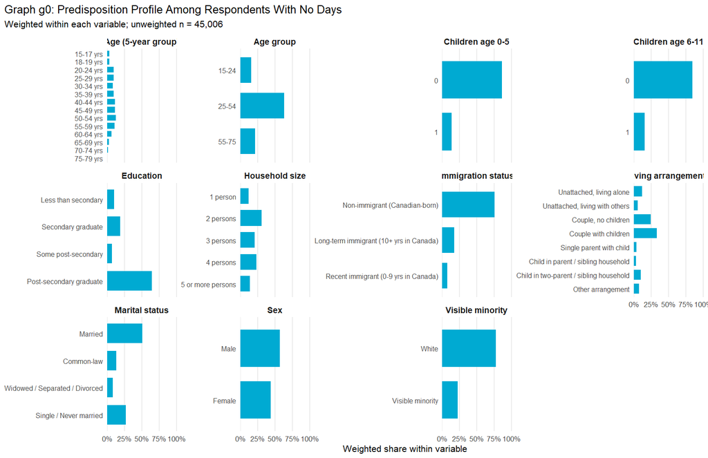

Graph g0: Weighted composition of the non-student predisposing variables among 45,006 respondents who reported No Days. Percentages sum to 100% within each variable.

### g01 - A4 Landscape Design

Graph g01 tests the same content at A4 landscape dimensions. Three facet columns, larger labels, and direct percentages trade browser compactness for print legibility.

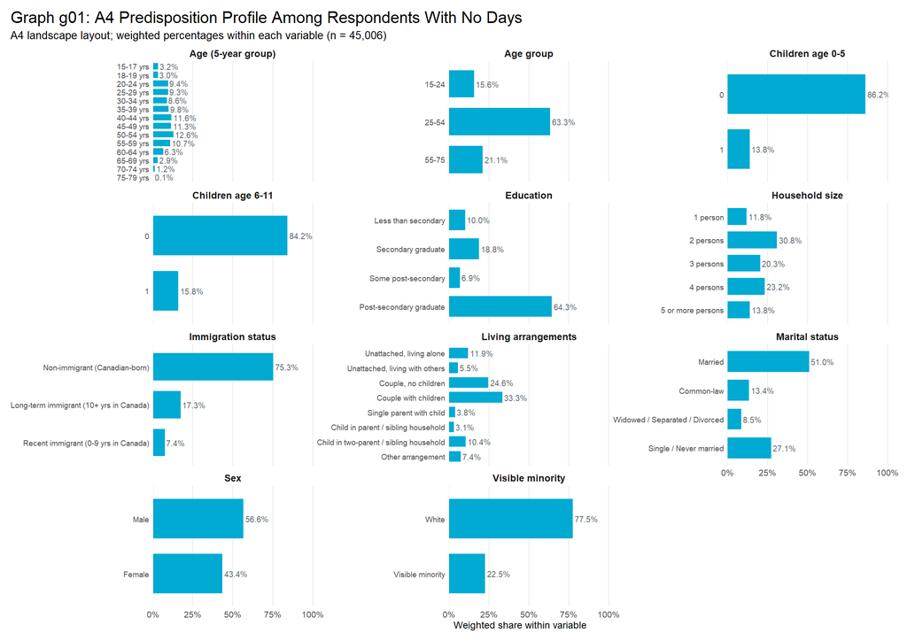

Graph g01: A4-landscape version of the No Days predisposition profile. Direct labels and a three-column facet layout are designed to remain legible in the browser and on an A4 landscape page.

## Graph Family g1: Chronic-Day Scale Design

The exact support contains integer values from 1 through 31. Graph g1 exposes rather than hides the consequence of each coarsening rule: exact values, five-day work-week bins, and a hybrid that retains one-day granularity through day 5 before coarsening.

**Map every exact chronic-day value to each proposed scale**

```r
g1_scale_mapping <- tidyr::crossing(
  days_absent_chronic = 1:31,
  scale = factor(
    c("Exact reported days", "Five-day work weeks", "First week exact; tail coarsened"),
    levels = c("Exact reported days", "First week exact; tail coarsened", "Five-day work weeks")
  )
) %>%
  mutate(
    bin_index = case_when(
      scale == "Exact reported days" ~ days_absent_chronic,
      scale == "Five-day work weeks" ~ ceiling(days_absent_chronic / 5),
      days_absent_chronic <= 5 ~ days_absent_chronic,
      TRUE ~ 5 + ceiling((days_absent_chronic - 5) / 5)
    ),
    bin_label = case_when(
      scale == "Exact reported days" ~ as.character(days_absent_chronic),
      scale == "Five-day work weeks" & days_absent_chronic == 31 ~ "7+ weeks",
      scale == "Five-day work weeks" ~ paste0(ceiling(days_absent_chronic / 5), " week", if_else(ceiling(days_absent_chronic / 5) == 1, "", "s")),
      days_absent_chronic <= 5 ~ paste0(days_absent_chronic, " day", if_else(days_absent_chronic == 1, "", "s")),
      days_absent_chronic == 31 ~ "31 days",
      TRUE ~ paste0((ceiling((days_absent_chronic - 5) / 5) - 1) * 5 + 6, "-", ceiling((days_absent_chronic - 5) / 5) * 5 + 5, " days")
    ),
    band = factor(bin_index %% 2)
  )

g1_scale_labels <- g1_scale_mapping %>%
  group_by(scale, bin_index, bin_label) %>%
  summarise(label_x = mean(days_absent_chronic), .groups = "drop")
```

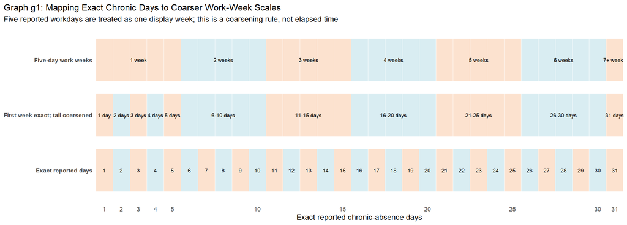

Graph g1: Every exact chronic-day value from 1 to 31 mapped to the raw, five-day work-week, and first-week-exact scales. Alternating bands reveal bin boundaries; labels state the category readers would see.

### g11 - Chronic-Day Distribution at Three Scales

Graph g11 adopts the left-hand three-way cohort partition from EDA-71 graph g22. The three stacked panels at right hold the same 3,626 Chronic respondents (defined as respondents with at least one chronic day) at the exact, five-day work-week, and first-week-exact scales. The top panel uses an exact-day colour category; the lower panels use the seven five-day work-week colour bands. Therefore, in the bottom panel days 1 through 5 remain separate bars while sharing the first work-week colour.

**Prepare the three-way cohort partition and chronic-day frequencies at three scales**

```r
# Extend the EDA-71 G22 composition: the unchanged three-way respondent partition
# sits at left, while the chronic-reporter distribution is shown at three scales.
g11_partition_summary <- ds0 %>%
  filter(!is.na(outcome_group)) %>%
  count(outcome_group, name = "n_raw") %>%
  mutate(
    pct_raw = n_raw / sum(n_raw) * 100,
    outcome_group = factor(outcome_group, levels = outcome_group_levels)
  )

g11_chronic_exact <- ds0 %>%
  filter(outcome_group == "Chronic Days") %>%
  count(days_absent_chronic, name = "n_raw") %>%
  tidyr::complete(days_absent_chronic = 1:31, fill = list(n_raw = 0L)) %>%
  mutate(
    exact_day = factor(days_absent_chronic, levels = 1:31),
    work_week = pmin(ceiling(days_absent_chronic / 5), 7L),
    work_week_label = factor(
      case_when(
        work_week == 1 ~ "1-5 days (1 week)",
        work_week == 2 ~ "6-10 days (2 weeks)",
        work_week == 3 ~ "11-15 days (3 weeks)",
        work_week == 4 ~ "16-20 days (4 weeks)",
        work_week == 5 ~ "21-25 days (5 weeks)",
        work_week == 6 ~ "26-30 days (6 weeks)",
        TRUE ~ "31 days (7+ weeks)"
      ),
      levels = c(
        "1-5 days (1 week)", "6-10 days (2 weeks)",
        "11-15 days (3 weeks)", "16-20 days (4 weeks)",
        "21-25 days (5 weeks)", "26-30 days (6 weeks)",
        "31 days (7+ weeks)"
      )
    ),
    hybrid_label = factor(
      case_when(
        days_absent_chronic <= 5 ~ paste0(days_absent_chronic, " day", if_else(days_absent_chronic == 1, "", "s")),
        days_absent_chronic <= 10 ~ "6-10 days",
        days_absent_chronic <= 15 ~ "11-15 days",
        days_absent_chronic <= 20 ~ "16-20 days",
        days_absent_chronic <= 25 ~ "21-25 days",
        days_absent_chronic <= 30 ~ "26-30 days",
        TRUE ~ "31 days"
      ),
      levels = c("1 day", "2 days", "3 days", "4 days", "5 days", "6-10 days",
                 "11-15 days", "16-20 days", "21-25 days", "26-30 days", "31 days")
    )
  )

g11_weekly <- g11_chronic_exact %>%
  group_by(work_week, work_week_label) %>%
  summarise(n_raw = sum(n_raw), .groups = "drop")

g11_hybrid <- g11_chronic_exact %>%
  group_by(hybrid_label, work_week_label) %>%
  summarise(n_raw = sum(n_raw), .groups = "drop")

g11_partition_colours <- c(
  "No Days" = "#D9D9D9",
  "Chronic Days" = "#D08C60",
  "Non-Chronic Days" = "#0B4F6C"
)
g11_exact_colours <- stats::setNames(grDevices::hcl.colors(31, "YlOrRd", rev = TRUE), as.character(1:31))
g11_week_colours <- stats::setNames(
  grDevices::hcl.colors(7, "YlOrRd", rev = TRUE),
  levels(g11_chronic_exact$work_week_label)
)
```

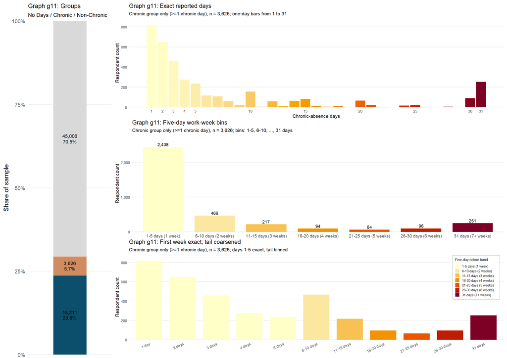

Graph g11: Left panel shows all three outcome groups (No Days n=45,006; Chronic n=3,626; Non-Chronic n=15,211). Right panels use the Chronic group only (>=1 chronic day; n=3,626): exact-day bars, five-day bins, and first-week-exact tail coarsening.

### g12 - Hybrid Missed-Day Distributions by Positive-Day Group

Graph g12 now keeps the left-hand three-way stacked partition and adds a right-hand comparison for the two positive-day groups only: Chronic (>=1 chronic day; n=3,626) and Non-Chronic (>0 missed days and 0 chronic days; n=15,211). Within each group, the first panel preserves days 1 through 5 while the second panel groups the remaining tail into work-week bins 2 through 7+. Panel widths are proportional to their five and six bars, so an individual bar occupies approximately the same width on both sides.

**Prepare hybrid missed-day frequencies for Chronic and Non-Chronic Days groups**

```r
# Compare the hybrid missed-day distribution for the two positive-day groups.
g12_partition_summary <- g11_partition_summary

g12_hybrid_distribution <- ds0 %>%
  filter(outcome_group %in% c("Chronic Days", "Non-Chronic Days")) %>%
  transmute(
    outcome_group,
    missed_days = if_else(
      outcome_group == "Chronic Days",
      days_absent_chronic,
      as.integer(days_absent_total)
    )
  ) %>%
  mutate(
    bin_index = case_when(
      missed_days <= 5 ~ missed_days,
      missed_days <= 10 ~ 6L,
      missed_days <= 15 ~ 7L,
      missed_days <= 20 ~ 8L,
      missed_days <= 25 ~ 9L,
      missed_days <= 30 ~ 10L,
      TRUE ~ 11L
    )
  ) %>%
  count(outcome_group, bin_index, name = "n_raw") %>%
  tidyr::complete(
    outcome_group = factor(
      c("Chronic Days", "Non-Chronic Days"),
      levels = c("Chronic Days", "Non-Chronic Days")
    ),
    bin_index = 1:11,
    fill = list(n_raw = 0L)
  ) %>%
  mutate(
    scale_panel = factor(
      if_else(bin_index <= 5, "A Week or Less", "More than a Week"),
      levels = c("A Week or Less", "More than a Week")
    ),
    bin_label = factor(
      case_when(
        bin_index <= 5 ~ as.character(bin_index),
        bin_index == 6 ~ "2",
        bin_index == 7 ~ "3",
        bin_index == 8 ~ "4",
        bin_index == 9 ~ "5",
        bin_index == 10 ~ "6",
        TRUE ~ "7+"
      ),
      levels = c("1", "2", "3", "4", "5", "6", "7+")
    ),
    work_week = factor(
      if_else(bin_index <= 5, 1L, bin_index - 4L),
      levels = 1:7
    )
  )
```

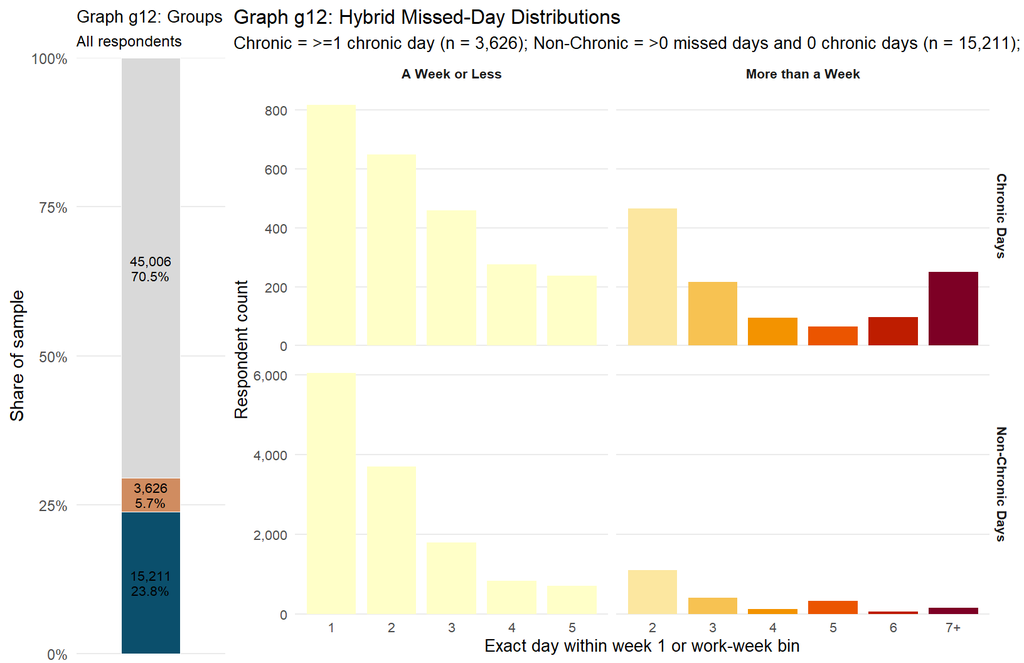

Graph g12: Left panel shows the full three-group partition (No Days, Chronic, Non-Chronic). Right panels use only Chronic (>=1 chronic day; n=3,626) and Non-Chronic (>0 missed days and 0 chronic days; n=15,211). Days 1-5 remain exact; values above day 5 are grouped into work-week bins 2 through 7+.

## Graph Family g2: Outcome-Group Predisposition Comparisons

This family compares group composition before moving to the numeric chronic-day values. Percentages in g2, g20, g21, g211, and g212 use the pooled survey weight. Graphs g22 through g24 condition on the 3,626 Chronic Days respondents.

**Prepare weighted composition contrasts and chronic-day intensity**

```r
g2_composition_all <- predictor_long %>%
  filter(outcome_group %in% outcome_group_levels, !is.na(level)) %>%
  group_by(outcome_group, variable, variable_label, level) %>%
  summarise(
    n_raw = n(),
    weight_sum = sum(weight_value, na.rm = TRUE),
    .groups = "drop_last"
  ) %>%
  mutate(
    pct_raw = n_raw / sum(n_raw) * 100,
    pct_weighted = weight_sum / sum(weight_sum) * 100
  ) %>%
  ungroup() %>%
  mutate(outcome_group = factor(outcome_group, levels = outcome_group_levels)) %>%
  add_facet_level()

g2_composition <- g2_composition_all %>%
  filter(outcome_group %in% comparison_group_levels) %>%
  mutate(outcome_group = factor(outcome_group, levels = comparison_group_levels))

g2_difference <- g2_composition %>%
  select(variable, variable_label, level, outcome_group, pct_weighted, facet_level) %>%
  tidyr::pivot_wider(names_from = outcome_group, values_from = pct_weighted) %>%
  mutate(difference_pp = `Chronic Days` - `No Days`)

g2_pairwise_differences <- g2_composition_all %>%
  select(variable, variable_label, level, outcome_group, pct_weighted, facet_level) %>%
  tidyr::pivot_wider(names_from = outcome_group, values_from = pct_weighted) %>%
  mutate(
    non_chronic_minus_no_days = `Non-Chronic Days` - `No Days`,
    chronic_minus_non_chronic = `Chronic Days` - `Non-Chronic Days`
  )

g2_intensity <- predictor_long %>%
  filter(outcome_group == "Chronic Days", !is.na(level)) %>%
  group_by(variable, variable_label, level) %>%
  summarise(
    n_raw = n(),
    mean_chronic_days = weighted_mean(days_absent_chronic, weight_value),
    .groups = "drop"
  ) %>%
  add_facet_level()

g2_exact_distribution <- predictor_long %>%
  filter(outcome_group == "Chronic Days", !is.na(level)) %>%
  group_by(variable, variable_label, level, days_absent_chronic) %>%
  summarise(weight_sum = sum(weight_value, na.rm = TRUE), .groups = "drop_last") %>%
  tidyr::complete(days_absent_chronic = 1:31, fill = list(weight_sum = 0)) %>%
  mutate(pct_within_level = weight_sum / sum(weight_sum) * 100) %>%
  ungroup() %>%
  add_facet_level()
```

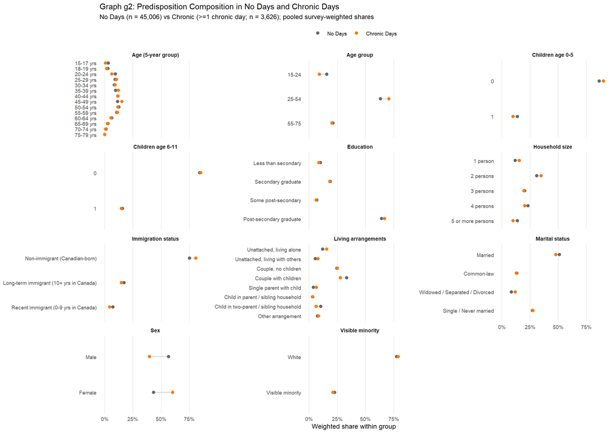

Graph g2: Pooled survey-weighted composition of No Days (n=45,006) and Chronic respondents (>=1 chronic day; n=3,626) within each predisposing variable.

### g20 - Composition Across All Three Groups

Graph g20 adds the Non-Chronic Days group to the same canvas. Its grey, brown, and blue group colours match EDA-71 graph g2 so the outcome partition remains visually consistent across reports.

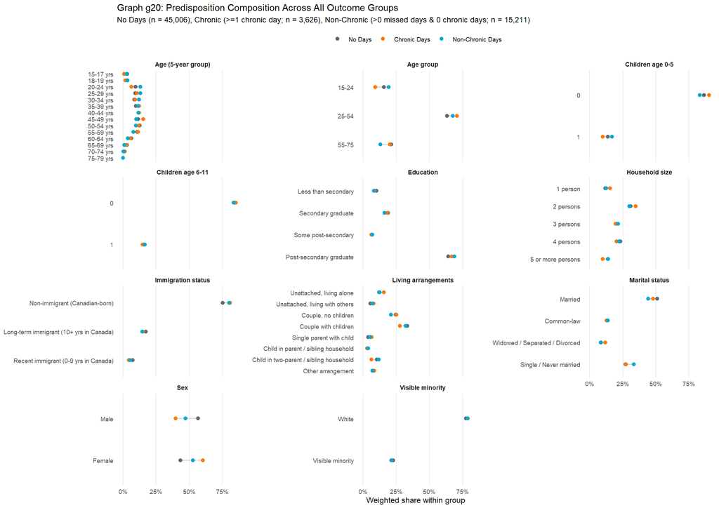

Graph g20: Pooled survey-weighted composition across No Days (n=45,006), Chronic (>=1 chronic day; n=3,626), and Non-Chronic (>0 missed days and 0 chronic days; n=15,211). Colours reproduce the EDA-71 graph g2 outcome palette.

### g21 - Composition Difference

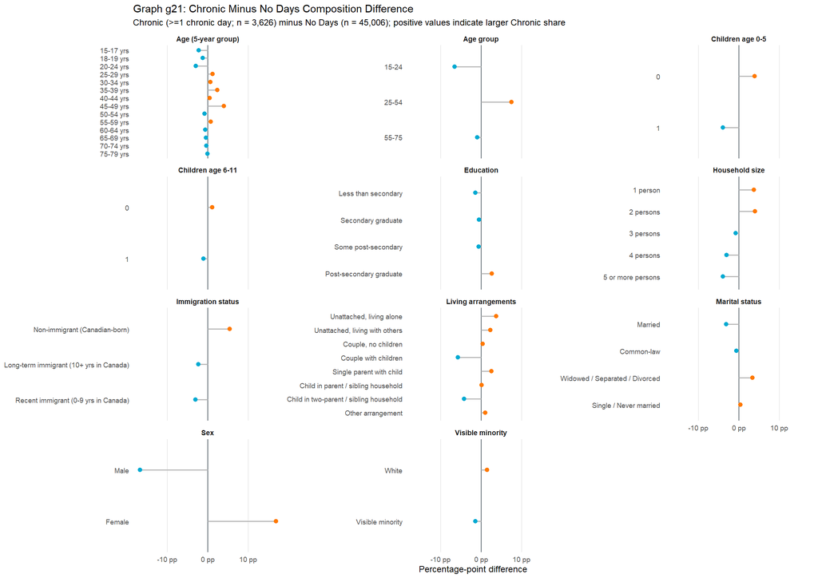

Graph g21: Weighted percentage-point difference calculated as Chronic (>=1 chronic day; n=3,626) minus No Days (n=45,006) for each predictor level.

#### g211 - Non-Chronic Minus No Days

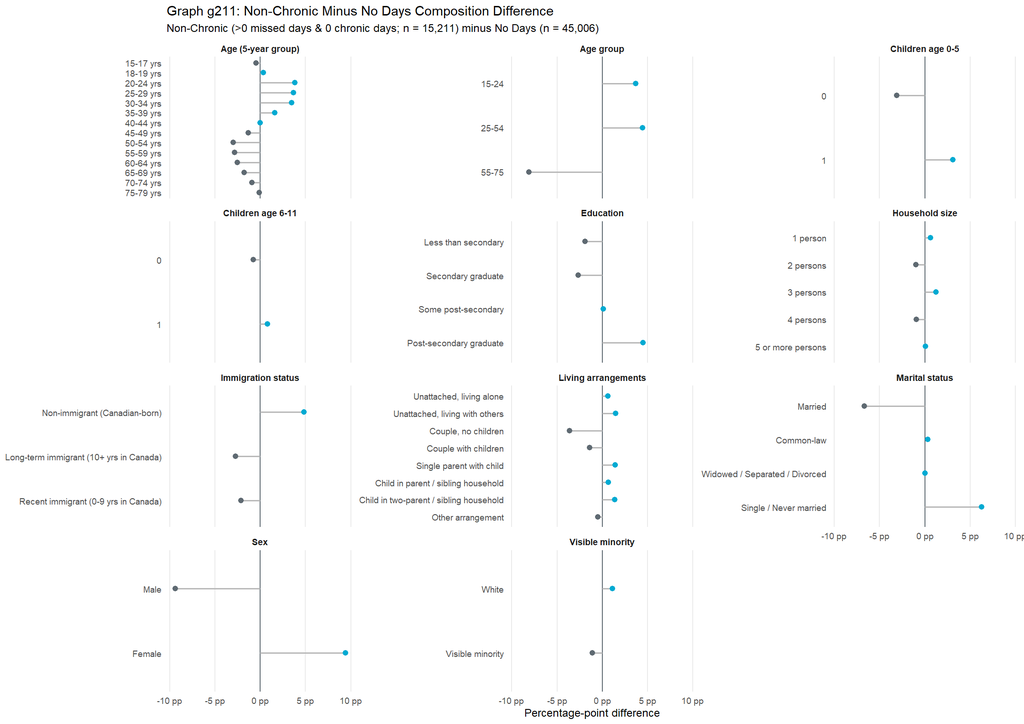

Graph g211: Weighted percentage-point difference calculated as Non-Chronic (>0 missed days and 0 chronic days; n=15,211) minus No Days (n=45,006) for each predictor level.

#### g212 - Chronic Minus Non-Chronic Days

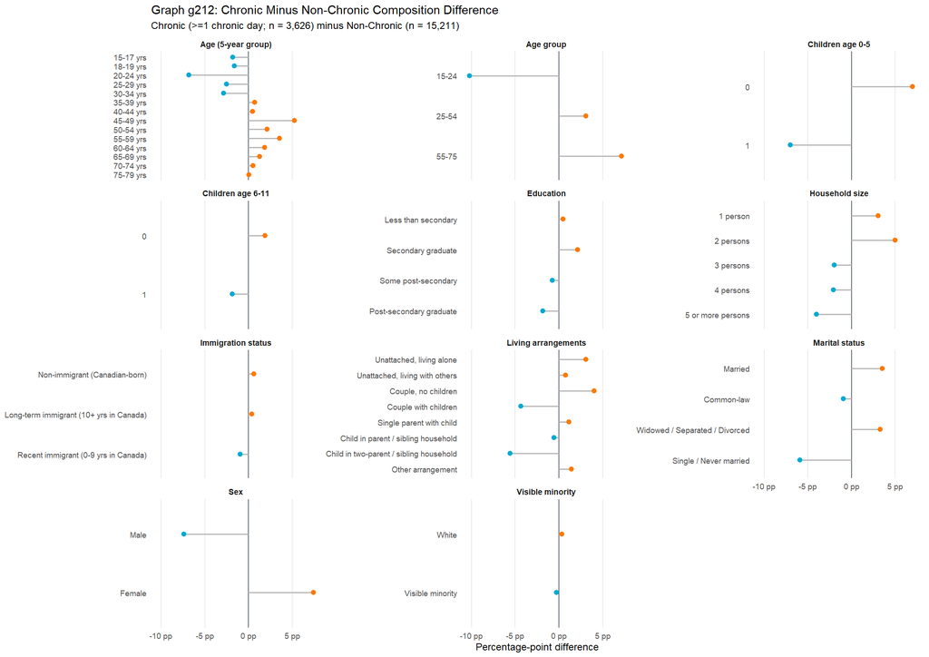

Graph g212: Weighted percentage-point difference calculated as Chronic (>=1 chronic day; n=3,626) minus Non-Chronic (>0 missed days and 0 chronic days; n=15,211) for each predictor level.

### g22 - Chronic-Day Intensity

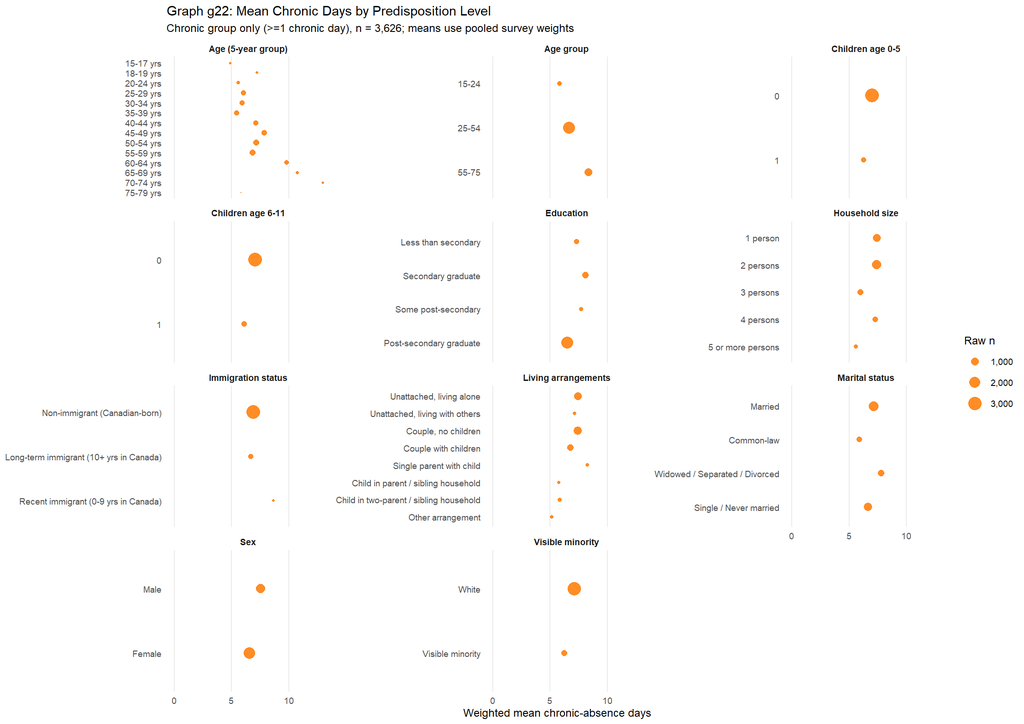

Graph g22: Pooled survey-weighted mean chronic-absence days within each predictor level among Chronic respondents only (>=1 chronic day; n=3,626).

### g23 - Exact Positive-Day Distribution

Graph g23 continues the thought of EDA-71’s `g23_chronic_vs_other_only_split_distribution`: it preserves every exact positive chronic-day value, but replaces the other-only comparison with predisposing-variable levels. Each row has its own 100% conditional denominator.

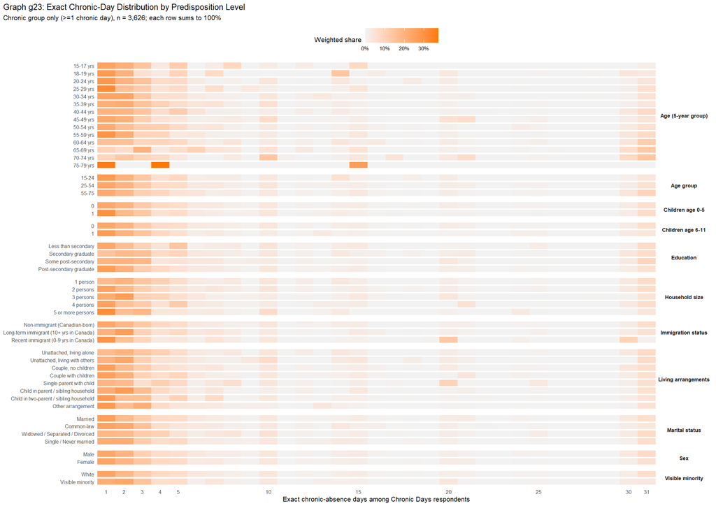

Graph g23: Exact chronic-day values among Chronic respondents only (>=1 chronic day; n=3,626), stratified by predisposing-variable level. Each row sums to 100%.

### g24 - Exact Distribution With Composition Tiles

Graph g24 retains g23’s exact-day matrix and adds two composition columns. The respondent-count column uses raw subgroup counts converted to shares, while the weighted-share column uses the pooled survey weight. Each column sums to 100% within a predictor, allowing levels such as age 15-24 to be read in context.

**Prepare raw respondent-count shares and weighted shares by predictor level**

```r
g24_composition_tiles <- g2_composition_all %>%
  filter(outcome_group == "Chronic Days") %>%
  select(variable, variable_label, facet_level, pct_raw, pct_weighted) %>%
  tidyr::pivot_longer(
    cols = c(pct_raw, pct_weighted),
    names_to = "measure",
    values_to = "share"
  ) %>%
  mutate(
    measure = factor(
      measure,
      levels = c("pct_raw", "pct_weighted"),
      labels = c("Respondent\nshare", "Weighted\nshare")
    )
  )

stopifnot(
  all(
    abs(
      g24_composition_tiles %>%
        group_by(variable, measure) %>%
        summarise(total = sum(share), .groups = "drop") %>%
        pull(total) - 100
    ) < 1e-8
  )
)
```

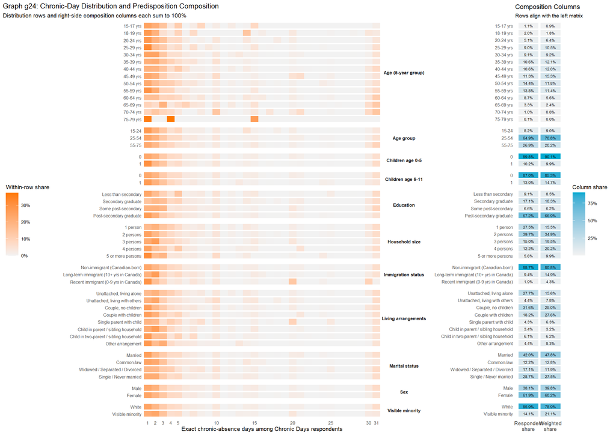

Graph g24: Left matrix shows exact chronic-day distributions; right columns show respondent-count share and weighted share. Rows are aligned so each category appears on the same row on both sides.

# Appendix

Student status is excluded because the source field is suppressed and all-missing in the PUMF. The three outcome groups are exhaustive and mutually exclusive; the added graphs now show their complete composition comparison matrix.